# Darren Wilkinson pMCMC example

This is an example R Notebook that is based on an [example by Darren Wilkinson](https://darrenjw.wordpress.com/2011/11/12/particle-filtering-and-pmcmc-using-r/).

## Setup

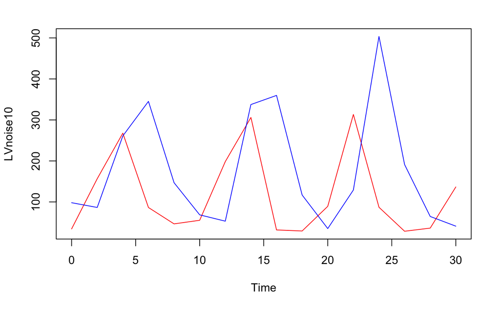

```r
require(smfsb)
data(LVdata)
#stepLVc(c(x1=50,x2=100),0,1)
plot(LVnoise10,plot.type="single",col=c(2,4))
```

## Particle filter

One of the key ingredients required to implement the pseudo-marginal MCMC scheme is a (bootstrap) particle filter which generates an unbiased estimate of the marginal likelihood of the data given the parameters (integrated over the unobserved state trajectory). The algorithm was discussed in this post, and R code to implement this is included in the `smfsb` R package as `pfMLLik. For reasons of numerical stability, the function computes and returns the log of the marginal likelihood, but it is important to understand that it is the actually likelihood estimate that is unbiased for the true likelihood, and not the corresponding statement for the logs. The actual code of the function is relatively short, and for completeness is given below:

```r
# arguments for pfMLLik: n = # particles, simx0 = initial conditions for all particles, t0 = starting point of Markov process, stepFun = function to advance Markov process, dataLik = likelihood of the observation, data = empirical data
pfMLLik <- function (n, simx0, t0, stepFun, dataLik, data)
{
    times = c(t0, as.numeric(rownames(data)))
    deltas = diff(times)
    return(function(...) {
        xmat = simx0(n, t0, ...)
        ll = 0
        for (i in 1:length(deltas)) {
            xmat = t(apply(xmat, 1, stepFun, t0 = times[i], deltat = deltas[i], ...))
            w = apply(xmat, 1, dataLik, t = times[i + 1], y = data[i,], log = FALSE, ...)
            if (max(w) < 1e-20) {
                warning("Particle filter bombed")
                return(-1e+99)
            }
            ll = ll + log(mean(w))
            rows = sample(1:n, n, replace = TRUE, prob = w)
            xmat = xmat[rows, ]
        }
        ll
    })
}
```

We need to set up the prior and the data likelihood correctly before we can use this function, but first note that the function does not actually run a particle filter at all, but instead stores everything it needs to know to run the particle filter in the local environment, and then returns a function closure for evaluating the marginal likelihood at a given set of parameters. The resulting function (closure) can then be used to run a particle filter for a given set of parameters, simply by passing the required parameters into the function. […] To use `pfMLLik`, we first need to define a function which evaluates the log-likelihood of an observation conditional on the true state, and another which samples from the prior distribution of the initial state of the system. Here, we can do that as follows.

```r
# set up data likelihood
noiseSD=10
dataLik <- function(x,t,y,log=TRUE,...)
{
    ll=sum(dnorm(y,x,noiseSD,log=TRUE))
    if (log)
        return(ll)
    else
        return(exp(ll))
}
# now define a sampler for the prior on the initial state
simx0 <- function(N,t0,...)
{
    mat=cbind(rpois(N,50),rpois(N,100))
    colnames(mat)=c("x1","x2")
    mat
}
# convert the time series to a timed data matrix
LVdata=as.timedData(LVnoise10)
# create marginal log-likelihood functions, based on a particle filter
# mLLik arguments: n = # particles, simx0 = initial conditions for all particles, t0 = starting point of Markov process, stepFun = function to advance Markov process, dataLik = likelihood of the observation, data = empirical data
mLLik=pfMLLik(100,simx0,0,stepLVc,dataLik,LVdata)
```

Now the function (closure) `mLLik` will, for a given parameter vector, run a particle filter (using 100 particles) and return the log of the particle filter’s unbiased estimate of the marginal likelihood of the data. It is then very easy to use this function to create a simple PMMH algorithm for parameter inference.

```r
mcmcSummary(thmat, rows = 3) # rows refers to number of variables per plot page
```

[output not shown]